# Assignment: Prediction Assignment Writeup

January 31, 2016

## Background

Using devices such as Jawbone Up, Nike FuelBand, and Fitbit it is now possible to collect a large amount of data about personal activity relatively inexpensively. These type of devices are part of the quantified self movement – a group of enthusiasts who take measurements about themselves regularly to improve their health, to find patterns in their behavior, or because they are tech geeks. One thing that people regularly do is quantify how much of a particular activity they do, but they rarely quantify how well they do it. In this project, your goal will be to use data from accelerometers on the belt, forearm, arm, and dumbell of 6 participants. They were asked to perform barbell lifts correctly and incorrectly in 5 different ways. More information is available from the website here: http://groupware.les.inf.puc-rio.br/har (see the section on the Weight Lifting Exercise Dataset).

## Data

The training data for this project are available here: https://d396qusza40orc.cloudfront.net/predmachlearn/pml-training.csv

The test data are available here: https://d396qusza40orc.cloudfront.net/predmachlearn/pml-testing.csv

```r
## Load libraries needed
library(caret)
library(randomForest)
library(gbm)
# Read in the data to use.
training = read.csv("~/Desktop/pml-training.csv", na.strings=c("","NA"))
testing = read.csv("~/Desktop/pml-testing.csv", na.strings=c("","NA"))
```

## Exploring The Data

```r
names(training)
```

```
##   [1] "X"                        "user_name"
##   [3] "raw_timestamp_part_1"     "raw_timestamp_part_2"
##   [5] "cvtd_timestamp"           "new_window"
##   [7] "num_window"               "roll_belt"
##   [9] "pitch_belt"               "yaw_belt"
##  [11] "total_accel_belt"         "kurtosis_roll_belt"
##  [13] "kurtosis_picth_belt"      "kurtosis_yaw_belt"
##  [15] "skewness_roll_belt"       "skewness_roll_belt.1"
##  [17] "skewness_yaw_belt"        "max_roll_belt"
##  [19] "max_picth_belt"           "max_yaw_belt"
##  [21] "min_roll_belt"            "min_pitch_belt"
##  [23] "min_yaw_belt"             "amplitude_roll_belt"
##  [25] "amplitude_pitch_belt"     "amplitude_yaw_belt"
##  [27] "var_total_accel_belt"     "avg_roll_belt"
##  [29] "stddev_roll_belt"         "var_roll_belt"
```

[output cut: 65 more lines]

```r
## We see there are 160 variables and 19.6k rows in the training set.
dim(training)
```

```
## [1] 19622   160
```

```r
## There are 5 levels of "classe", A-E.
levels(training$classe)
```

```
## [1] "A" "B" "C" "D" "E"
```

```r
## We see there are 160 variables and 20 rows in the testing set.
dim(testing)
```

```
## [1]  20 160
```

```r
## By looking at the first 10 records in the testing set we can see there are a lot of NA values.
## The first 7 columns do not seem to be relevant to predictions.
names(testing)
```

[output not shown]

```
##   [1] "X"                        "user_name"
##   [3] "raw_timestamp_part_1"     "raw_timestamp_part_2"
##   [5] "cvtd_timestamp"           "new_window"
##   [7] "num_window"               "roll_belt"
##   [9] "pitch_belt"               "yaw_belt"
##  [11] "total_accel_belt"         "kurtosis_roll_belt"
##  [13] "kurtosis_picth_belt"      "kurtosis_yaw_belt"
##  [15] "skewness_roll_belt"       "skewness_roll_belt.1"
##  [17] "skewness_yaw_belt"        "max_roll_belt"
##  [19] "max_picth_belt"           "max_yaw_belt"
##  [21] "min_roll_belt"            "min_pitch_belt"
##  [23] "min_yaw_belt"             "amplitude_roll_belt"
##  [25] "amplitude_pitch_belt"     "amplitude_yaw_belt"
##  [27] "var_total_accel_belt"     "avg_roll_belt"
##  [29] "stddev_roll_belt"         "var_roll_belt"
```

[output cut: 65 more lines]

## Cleaning The Data

```r
## Use only relevant columns. Remove the first 7 columns
## (X, user_name, raw_timestamp_part_1, raw_timestamp_part_2, cvtd_timestamp, new_window, num_window)
trainingClean <- training[,-(1:7)]
testingClean <- testing[,-(1:7)]
## Remove columns with NA values.
trainingClean <- trainingClean[,colSums(is.na(trainingClean)) == 0]
testingClean <- testingClean[,colSums(is.na(testingClean)) == 0]
## We are left with 53 columns in the training set and 53 in the test set.
dim(trainingClean)
```

```
## [1] 19622    53
```

```r
dim(testingClean)
```

```
## [1] 20 53
```

## Split & Subset The Data

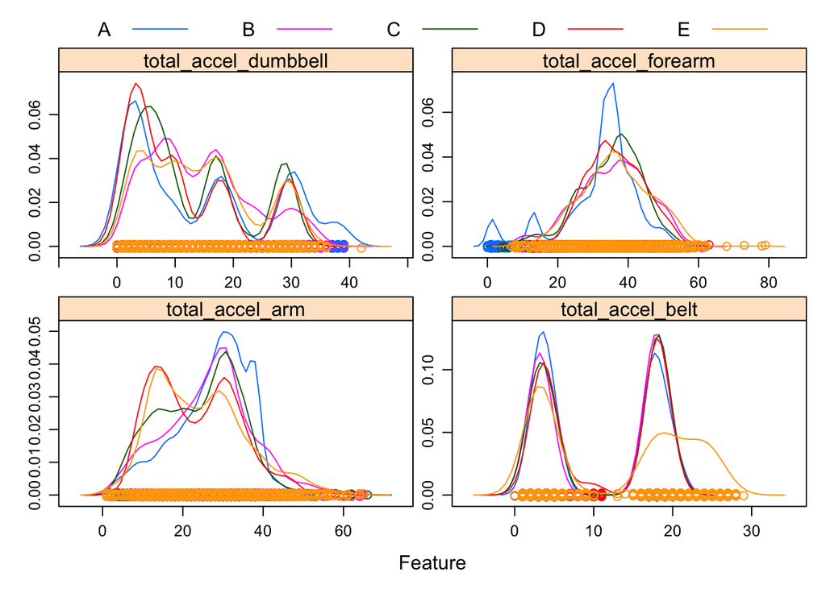

```r
## We need to split the data for training and validation.
## We will do a 70/30 split for training/validation.
inTrain <- createDataPartition(y=trainingClean$classe,p=0.7,list=FALSE)
trainingCleanSlice <- trainingClean[inTrain,]
validationCleanSlice <- trainingClean[-inTrain,]

## Subset the data to just the columns that contain totals
totalSubset <- trainingCleanSlice[, grepl("total", names(trainingCleanSlice))]

## Show a density plot for this data subset
featurePlot(x=totalSubset, y=trainingCleanSlice$classe, plot="density", scales=list(x=list(relation="free"), y=list(relation="free")), auto.key=list(columns=5))
```

## Prediction Models

```r
set.seed(32)

## boosting with trees method
modelGBM <- train(classe ~., data=trainingCleanSlice, method="gbm", verbose=FALSE)
print(modelGBM)
```

```
## Stochastic Gradient Boosting
##
## 13737 samples
##    52 predictor
##     5 classes: 'A', 'B', 'C', 'D', 'E'
##
## No pre-processing
## Resampling: Bootstrapped (25 reps)
## Summary of sample sizes: 13737, 13737, 13737, 13737, 13737, 13737, ...
## Resampling results across tuning parameters:
##
##   interaction.depth  n.trees  Accuracy   Kappa      Accuracy SD
##   1                   50      0.7518165  0.6853838  0.006093679
##   1                  100      0.8173449  0.7688715  0.005731982
##   1                  150      0.8506538  0.8110598  0.004284103
##   2                   50      0.8528452  0.8136017  0.006230532
##   2                  100      0.9022470  0.8763207  0.004966664
##   2                  150      0.9262707  0.9067224  0.004553814
##   3                   50      0.8927611  0.8642708  0.005601199
##   3                  100      0.9379562  0.9215113  0.003461577
##   3                  150      0.9560662  0.9444219  0.003472211
##   Kappa SD
##   0.007689443
##   0.007235681
##   0.005358455
##   0.007916886
##   0.006304542
##   0.005762582
##   0.007102990
##   0.004376172
##   0.004385211
##
## Tuning parameter 'shrinkage' was held constant at a value of 0.1
##
## Tuning parameter 'n.minobsinnode' was held constant at a value of 10
## Accuracy was used to select the optimal model using  the largest value.
## The final values used for the model were n.trees = 150,
##  interaction.depth = 3, shrinkage = 0.1 and n.minobsinnode = 10.
```

```r
modelGBM$finalModel
```

```
## A gradient boosted model with multinomial loss function.
## 150 iterations were performed.
## There were 52 predictors of which 41 had non-zero influence.
```

```r
predictGBM <- predict(modelGBM, testingClean)
summary(predictGBM)
```

```
## A B C D E
## 7 8 1 1 3
```

```r
## random forest method
modelRF <- train(classe ~., data=trainingCleanSlice, method="rf")
print(modelRF)
```

```
## Random Forest
##
## 13737 samples
##    52 predictor
##     5 classes: 'A', 'B', 'C', 'D', 'E'
##
## No pre-processing
## Resampling: Bootstrapped (25 reps)
## Summary of sample sizes: 13737, 13737, 13737, 13737, 13737, 13737, ...
## Resampling results across tuning parameters:
##
##   mtry  Accuracy   Kappa      Accuracy SD  Kappa SD
##    2    0.9890081  0.9860826  0.001905482  0.002404664
##   27    0.9892909  0.9864406  0.002065053  0.002613231
##   52    0.9794578  0.9739893  0.005107812  0.006472766
##
## Accuracy was used to select the optimal model using  the largest value.
## The final value used for the model was mtry = 27.
```

```r
modelRF$finalModel
```

```
##
## Call:
##  randomForest(x = x, y = y, mtry = param$mtry)
##                Type of random forest: classification
##                      Number of trees: 500
## No. of variables tried at each split: 27
##
##         OOB estimate of  error rate: 0.74%
## Confusion matrix:
##      A    B    C    D    E class.error
## A 3899    5    2    0    0 0.001792115
## B   18 2630   10    0    0 0.010534236
## C    0   12 2372   12    0 0.010016694
## D    0    1   27 2221    3 0.013765542
## E    0    2    3    7 2513 0.004752475
```

```r
predictRF <- predict(modelRF, testingClean)
predictRF
```

```
##  [1] B A B A A E D B A A B C B A E E A B B B
## Levels: A B C D E
```

```r
summary(predictRF)
```

```
## A B C D E
## 7 8 1 1 3
```

```r
predictRFValid <- predict(modelRF, validationCleanSlice)
results <- confusionMatrix(validationCleanSlice$classe, predictRFValid)
results
```

```
## Confusion Matrix and Statistics
##
##           Reference
## Prediction    A    B    C    D    E
##          A 1672    1    0    0    1
##          B    3 1135    1    0    0
##          C    0    7 1016    3    0
##          D    0    0   15  949    0
##          E    0    0    2    2 1078
##
## Overall Statistics
##
##                Accuracy : 0.9941
##                  95% CI : (0.9917, 0.9959)
##     No Information Rate : 0.2846
##     P-Value [Acc > NIR] : < 2.2e-16
##
##                   Kappa : 0.9925
##  Mcnemar's Test P-Value : NA
##
## Statistics by Class:
##
##                      Class: A Class: B Class: C Class: D Class: E
## Sensitivity            0.9982   0.9930   0.9826   0.9948   0.9991
## Specificity            0.9995   0.9992   0.9979   0.9970   0.9992
## Pos Pred Value         0.9988   0.9965   0.9903   0.9844   0.9963
## Neg Pred Value         0.9993   0.9983   0.9963   0.9990   0.9998
## Prevalence             0.2846   0.1942   0.1757   0.1621   0.1833
## Detection Rate         0.2841   0.1929   0.1726   0.1613   0.1832
## Detection Prevalence   0.2845   0.1935   0.1743   0.1638   0.1839
## Balanced Accuracy      0.9989   0.9961   0.9903   0.9959   0.9991
```

## Results

Testing two different prediction methods, it seems that predicting with random forests has a higher accuracy rate than gbm.